# **Dimensionality Reduction & Multivariate Modeling**

# Problem 2 (33 points)

In base **R**, there is a dataset called `penguins`. Type `?penguins` to read a little about the data.

```r
?penguins
```

### Part a (6 points)

Remove the rows in the penguins dataset that have missing values. Then use the `ggpairs()` function from `GGally` to make pairwise scatterplots for the four quantitative variables and color the points based on the `species` variable. Note that the `ggpairs()` function has a `columns` argument where you can select the columns you want to plot and it has a `mapping` argument where you can put `aes(color = species, alpha = 0.5)` to color the points by species.

Include the plot here and then comment on which scatterplots seem to nicely separate the penguins by species and which tend to have worse separation.

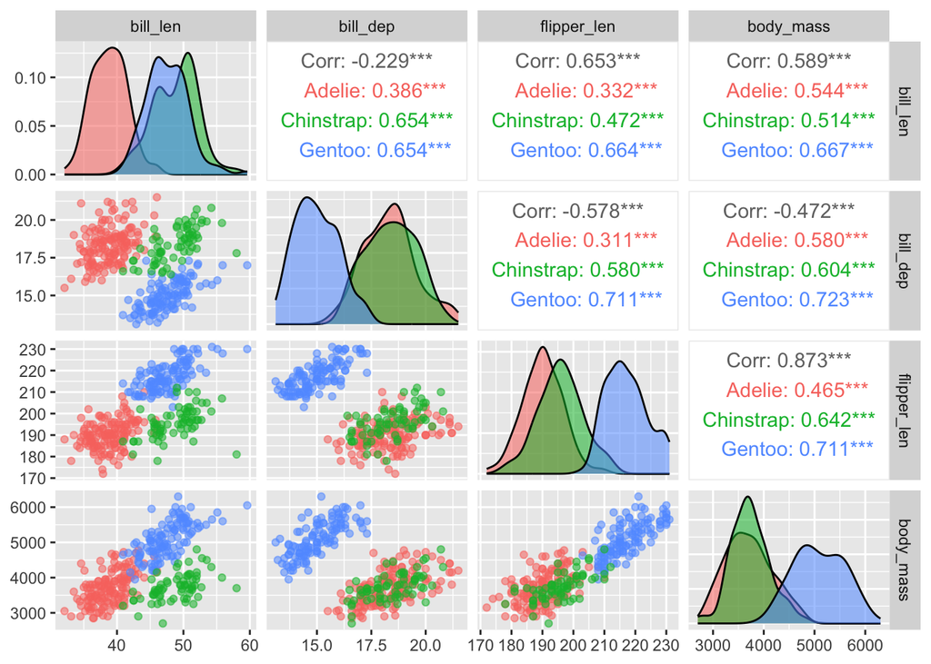

```r
library(GGally)
library(ggplot2)

penguins_clean <- na.omit(penguins)

ggpairs(
  data = penguins_clean,
  columns = c("bill_len", "bill_dep", "flipper_len", "body_mass"),
  mapping = aes(color = species, alpha = 0.5)
)
```

```r
# bill_len v. bill_dep have good separation
# bill_len v. flipper_len have good separation
# bill_len v. body_mass have decent separation
# bill_dep v. flipper_len have bad separation
# bill_dep v. body_mass have bad separation
# flipper_len v. body_mass have bad separation
```

[figure not shown]

Penguins Graphs

### Part b (4 points)

Run a scaled principal component analysis on the four quantitative variables using the `prcomp()` function. How much of the total variation in these variables is explained by the first two principal components? You can use the `summary()` function on your PCA to find this easily.

```r
pca_results = prcomp(penguins_clean[, c("bill_len", "bill_dep", "flipper_len", "body_mass")], scale = TRUE)
summary(pca_results)
```

```
Importance of components:
                          PC1    PC2     PC3     PC4
Standard deviation     1.6569 0.8821 0.60716 0.32846
Proportion of Variance 0.6863 0.1945 0.09216 0.02697
Cumulative Proportion  0.6863 0.8809 0.97303 1.00000
```

```r
# 0.8809 of the total variation is explained by the first two components.
```

### Part c (6 points)

Plot the first two principal components with PC1 on the x-axis and PC2 on the y-axis. Color the points by species and comment on how well the first two principal components are separating by species.

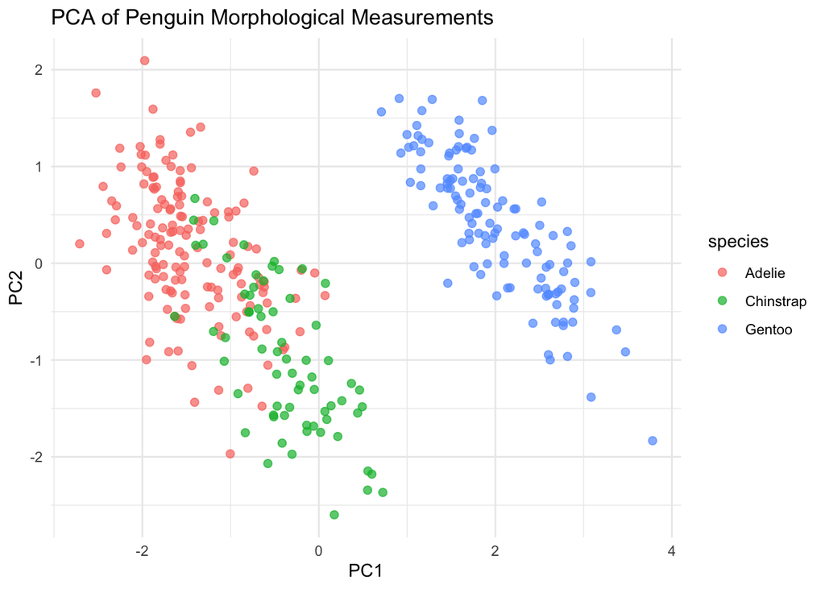

```r
pca_data = as.data.frame(pca_results$x)

pca_data$species = penguins_clean$species

ggplot(pca_data, aes(x = PC1, y = PC2, color = species)) +
  geom_point(alpha = 0.7, size = 2) +
  theme_minimal() +
  labs(
    title = "PCA of Penguin Morphological Measurements",
    x = "PC1",
    y = "PC2"
  )
```

```r
# The first two principal components aren't separating completely; there is a lot of overlap between the Adelie and Chinstrap species; however, the Gentoo species is completely distinct.
```

### Part d (12 points)

Now use the `umap()` function in the `umap` library to fit a UMAP to the **scaled** quantitative variables in the penguins dataset. You can use the `scale()` function to scale the variables. Make sure the UMAP gives two components and set a `random_state` in the function so your results are reproducible. Then plot the UMAP using the the `umap_plot()` function in `math3190package` and color the points by `species` using the `color_umap` argument. Experiment with at least three different number of neighbors (`n_neighbors`) and at least three different minimum distances (`min_dist`).

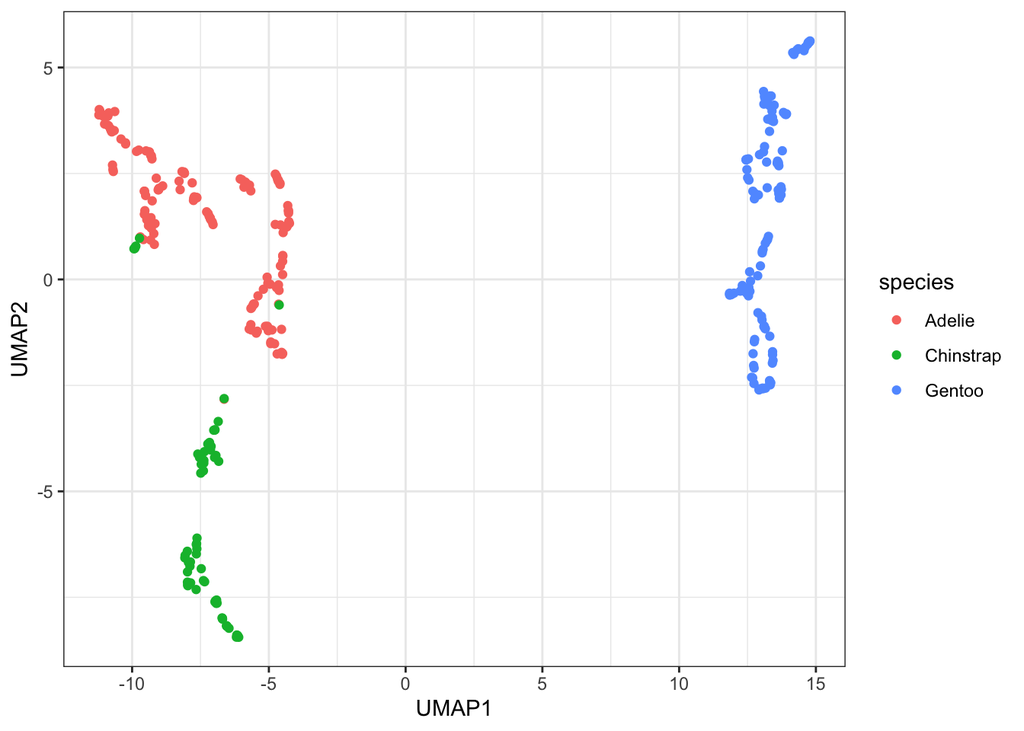

```r
library(umap)
library(math3190package)

quant_vars = penguins_clean[, c("bill_len", "bill_dep", "flipper_len", "body_mass")]

scaled_quant_vars = scale(quant_vars)

experiment_umap <- function(n_neigh, m_dist) {

  custom_umap_config <- umap.defaults
  custom_umap_config$n_components <- 2
  custom_umap_config$random_state <- 42
  custom_umap_config$n_neighbors <- n_neigh
  custom_umap_config$min_dist <- m_dist

  umap_results <- umap(scaled_quant_vars, config = custom_umap_config)

  umap_plot(umap_results,
            data = penguins_clean,
            color_umap = "species")
}

experiment_umap(n_neigh = 5, m_dist = 0.01)
```

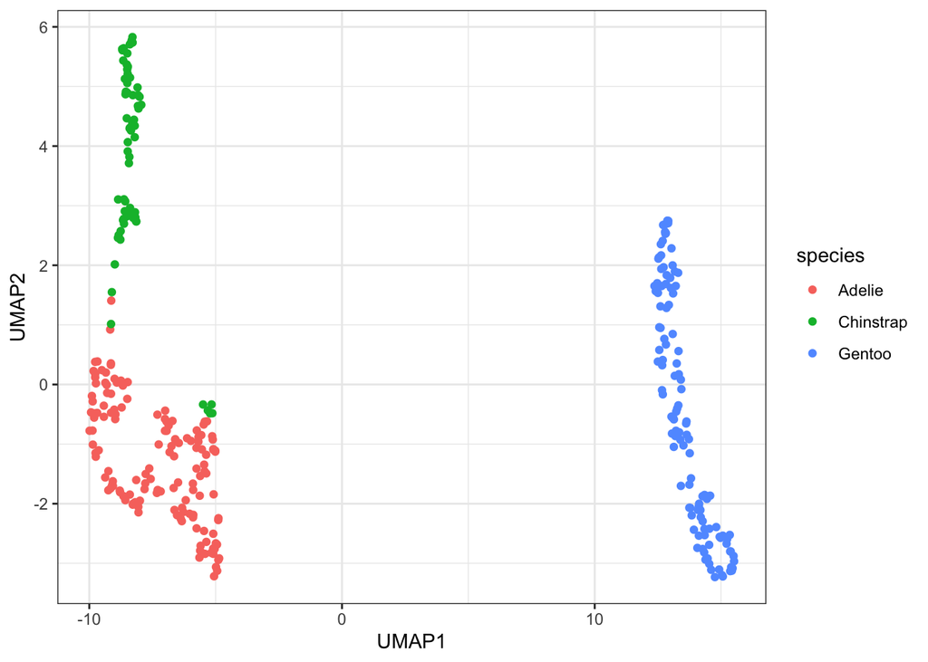

```r
experiment_umap(n_neigh = 15, m_dist = 0.1)
```